# Nanonets Assignment

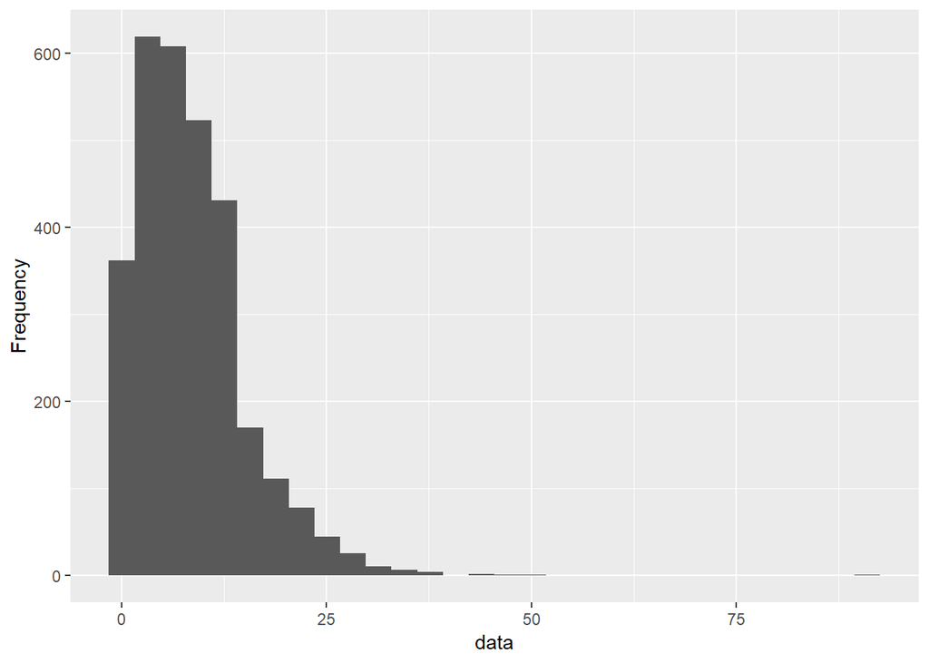

```r
#get count of crew gender = 2
total_tr_crew_gender_2 = apply(text, MARGIN=1, FUN=function(x2) gender_count(x2, id = "2"))
plot_histogram(total_tr_crew_gender_2)
```

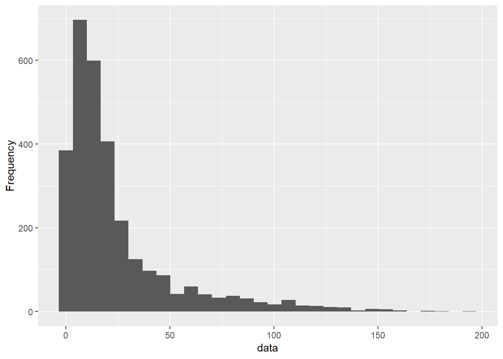

```r
#get count of total crew
total_tr_crew = apply(text, 1, get_crew)
plot_histogram(total_tr_crew)
```

```r
sum(total_tr_crew
    -total_tr_crew_gender_0
    -total_tr_crew_gender_1
    -total_tr_crew_gender_2) # should be zero
```

```
## [1] 0
```

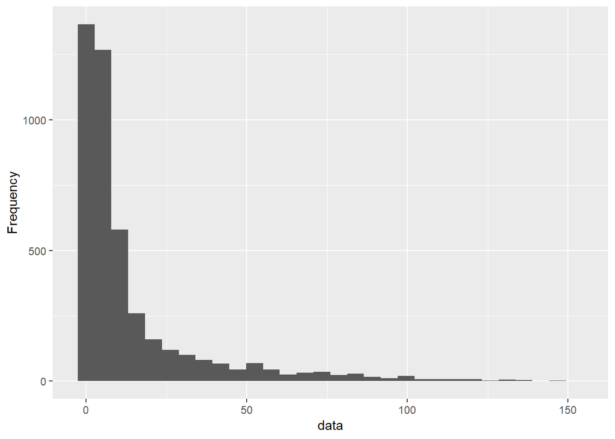

```r
# testing crew

text = test_data$crew
text = data.frame(text)

#get count of crew gender = 0
total_te_crew_gender_0 = apply(text, MARGIN=1, FUN=function(x2) gender_count(x2, id = "0"))
plot_histogram(total_te_crew_gender_0)
```

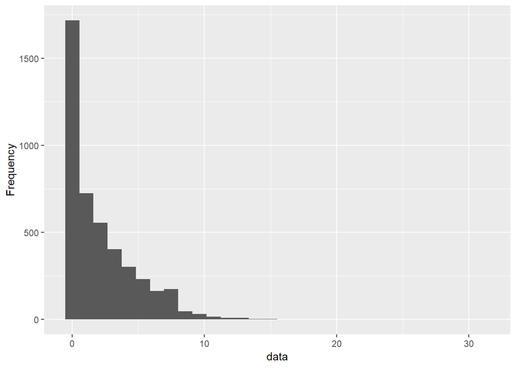

```r
#get count of crew gender = 1
total_te_crew_gender_1 = apply(text, MARGIN=1, FUN=function(x2) gender_count(x2, id = "1"))
plot_histogram(total_te_crew_gender_1)
```

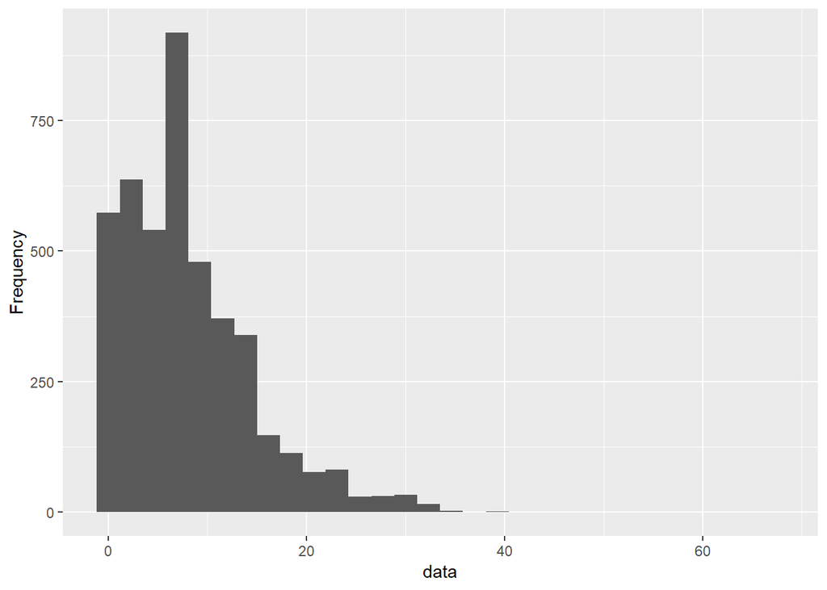

```r
#get count of crew gender = 2
total_te_crew_gender_2 = apply(text, MARGIN=1, FUN=function(x2) gender_count(x2, id = "2"))
plot_histogram(total_te_crew_gender_2)
```

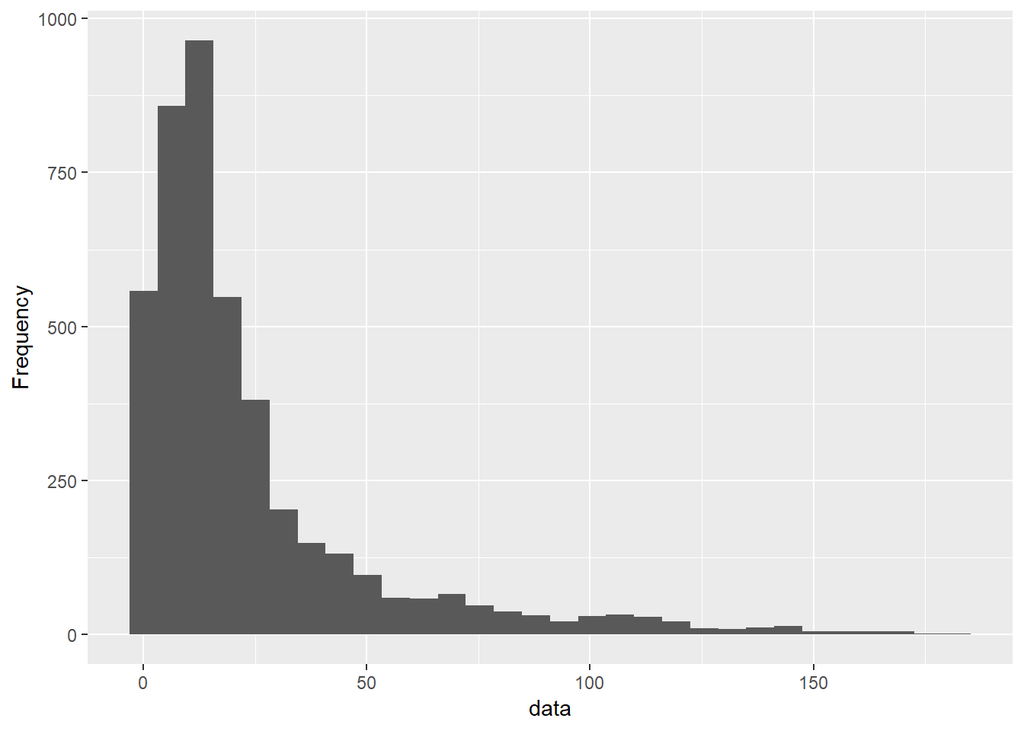

```r
#get count of total crew
total_te_crew = apply(text, 1, get_crew)
plot_histogram(total_te_crew)
```

```r
sum(total_te_crew
    -total_te_crew_gender_0
    -total_te_crew_gender_1
    -total_te_crew_gender_2) # should be zero
```

```
## [1] 0
```

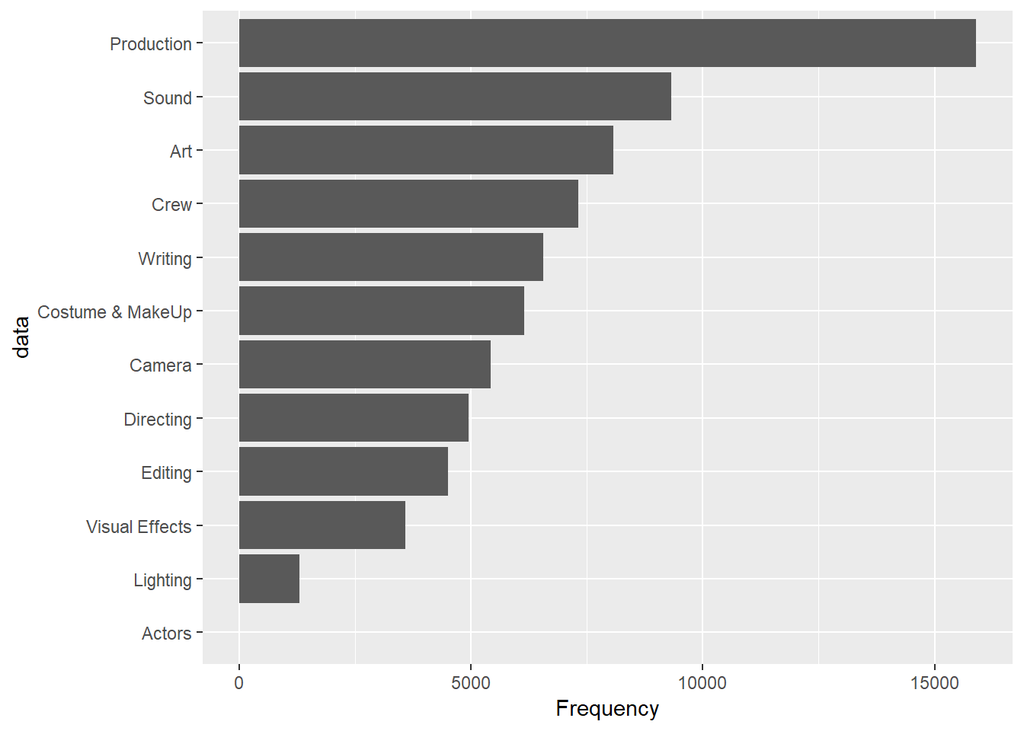

```r
# get department
text = paste0(train_data$crew[!is.na(train_data$crew)],collapse = " ")
total_department = get_department(text)
plot_bar(total_department)
```

```r
dept_list = unique(total_department)

dept_tr_data = matrix(0,nrow = nrow(train_data),ncol = length(dept_list))
dept_tr_data = data.frame(dept_tr_data)
colnames(dept_tr_data) = dept_list

# Hypothesis is that, some departments cost more than others and hence may have relation with
# budget and revenue
for(dept in dept_list){

  print(dept)
  dept_tr_data[,dept] = str_count(train_data$crew,dept) # get count

}
```

```
## [1] "Directing"
## [1] "Writing"
## [1] "Production"
## [1] "Sound"
## [1] "Camera"
## [1] "Editing"
## [1] "Art"
## [1] "Costume & MakeUp"
## [1] "Crew"
## [1] "Lighting"
## [1] "Visual Effects"
## [1] "Actors"
```

```r
dept_tr_data[is.na(dept_tr_data)] = 0
colSums(dept_tr_data,na.rm = TRUE) # the distribution
```

```
##        Directing          Writing       Production            Sound
##             4954             6589            19524            13283
##           Camera          Editing              Art Costume & MakeUp
##             6940             4539            12854                0
##             Crew         Lighting   Visual Effects           Actors
##             7316             1502             5981                4
```

```r
# testing department
dept_te_data = matrix(0,nrow = nrow(test_data),ncol = length(dept_list))
dept_te_data = data.frame(dept_te_data)
colnames(dept_te_data) = dept_list

# Hypothesis is that, some departments cost more than others and hence may have relation with
# budget and revenue
for(dept in dept_list){

  print(dept)
  dept_te_data[,dept] = str_count(test_data$crew,dept) # get count

}
```

```
## [1] "Directing"
## [1] "Writing"
## [1] "Production"
## [1] "Sound"
## [1] "Camera"
## [1] "Editing"
## [1] "Art"
## [1] "Costume & MakeUp"
## [1] "Crew"
## [1] "Lighting"
## [1] "Visual Effects"
## [1] "Actors"
```

```r
dept_te_data[is.na(dept_te_data)] = 0
colSums(dept_te_data,na.rm = TRUE) # the distribution
```

```
##        Directing          Writing       Production            Sound
##             7291             9793            28325            18738
##           Camera          Editing              Art Costume & MakeUp
##            10010             6676            18881                0
##             Crew         Lighting   Visual Effects           Actors
##            10214             2151             9517                1
```

```r
# Actors column due to very low frequency
dept_tr_data$Actors = NULL
dept_te_data$Actors = NULL

rm(text,dept,dept_list)
gc()
```

```
##            used  (Mb) gc trigger  (Mb) max used  (Mb)
## Ncells  3781060 202.0    6190957 330.7  6190957 330.7
## Vcells 17472014 133.4   56935500 434.4 56935046 434.4
```

**10. Original Language**

```r
# create new variables on original language

top_n_original_lang = train_data %>% count(original_language) %>% group_by(original_language)
top_n_original_lang = top_n_original_lang[order(top_n_original_lang$n,decreasing = TRUE),]

top_n_original_lang = top_n_original_lang[1:5,"original_language"]
top_n_original_lang = paste0(top_n_original_lang$original_language)

train_data$original_language[!train_data$original_language %in% top_n_original_lang] = "other"
test_data$original_language[!test_data$original_language %in% top_n_original_lang] = "other"
```

** 11. Budget, Popularity, Runtime, & Revenue**

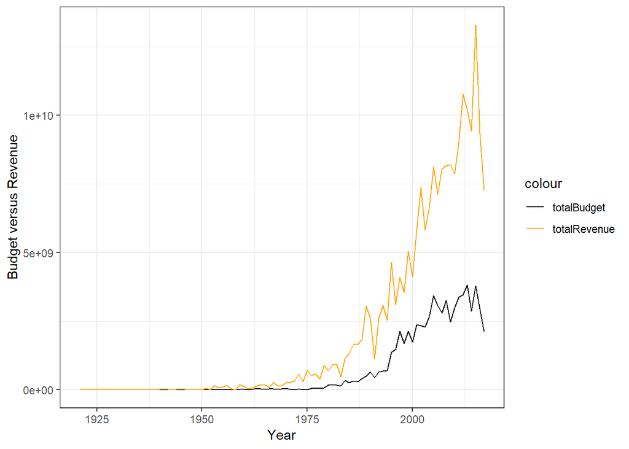

```r
col_name = c("budget","runtime","popularity","revenue")
train_data$year = as.character(train_data$year)

# Budget versus Revenue

train_data %>%
  group_by(year) %>%
  summarise(totalBudget = sum(as.numeric(budget), na.rm = TRUE),
            totalRevenue = sum(as.numeric(revenue), na.rm = TRUE)) %>%
  ggplot(aes(as.numeric(year)),group = 1)+
  geom_line(aes(y=totalBudget, color="totalBudget"))+
  geom_line(aes(y=totalRevenue, color="totalRevenue"))+
  scale_colour_manual(values=c("black", "orange"))+
  xlab("Year")+
  ylab("Budget versus Revenue")+
  theme_bw()
```

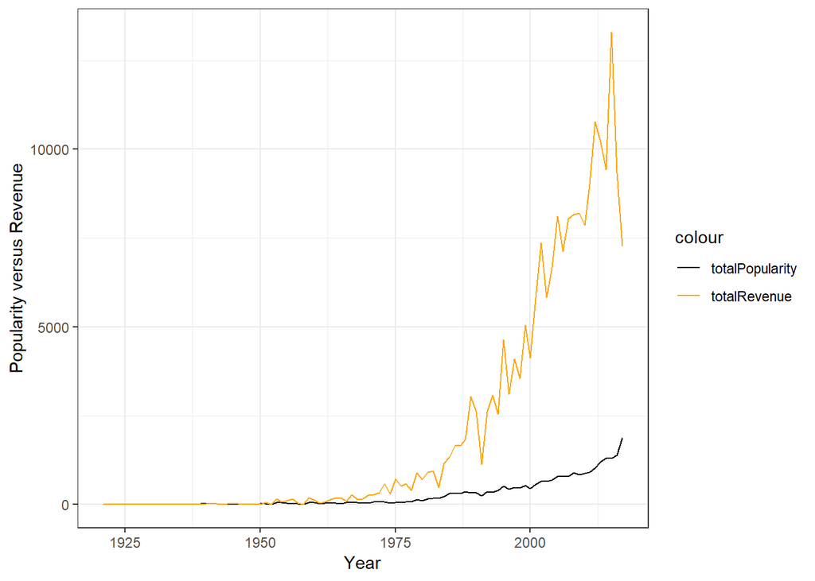

```r
#Popularity versus Revenue

train_data %>%
  group_by(year) %>%
  summarise(totalPopularity = sum(as.numeric(popularity), na.rm = TRUE),
            totalRevenue = sum(as.numeric(revenue), na.rm = TRUE)/1000000) %>%
  ggplot(aes(as.numeric(year)),group = 1)+
  geom_line(aes(y=totalPopularity, color="totalPopularity"))+
  geom_line(aes(y=totalRevenue, color="totalRevenue"))+
  scale_colour_manual(values=c("black", "orange"))+
  xlab("Year")+
  ylab("Popularity versus Revenue")+
  theme_bw()
```

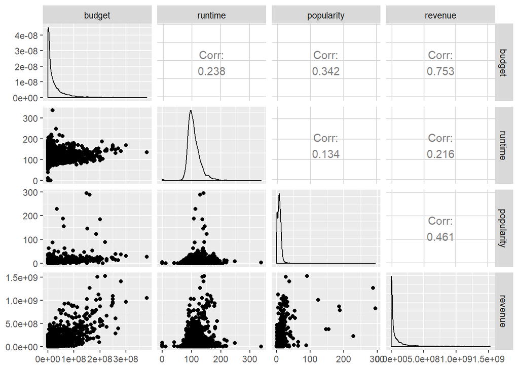

```r
# scatter-plot matrix
ggpairs(train_data[,col_name], alpha = 0.4)
```

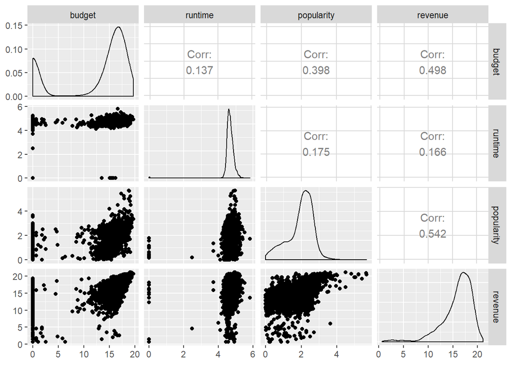

```r
ggpairs(log(train_data[,col_name]+1), alpha = 0.4) # log
```

**log of budget has bi-modal distribution** **log of runtime has tigh and peaked distribution** ** log of popularity follows a normal distribution log of revenue has skewed distribution (negative) data has outliers taking log of data will help in dealing with such cases**

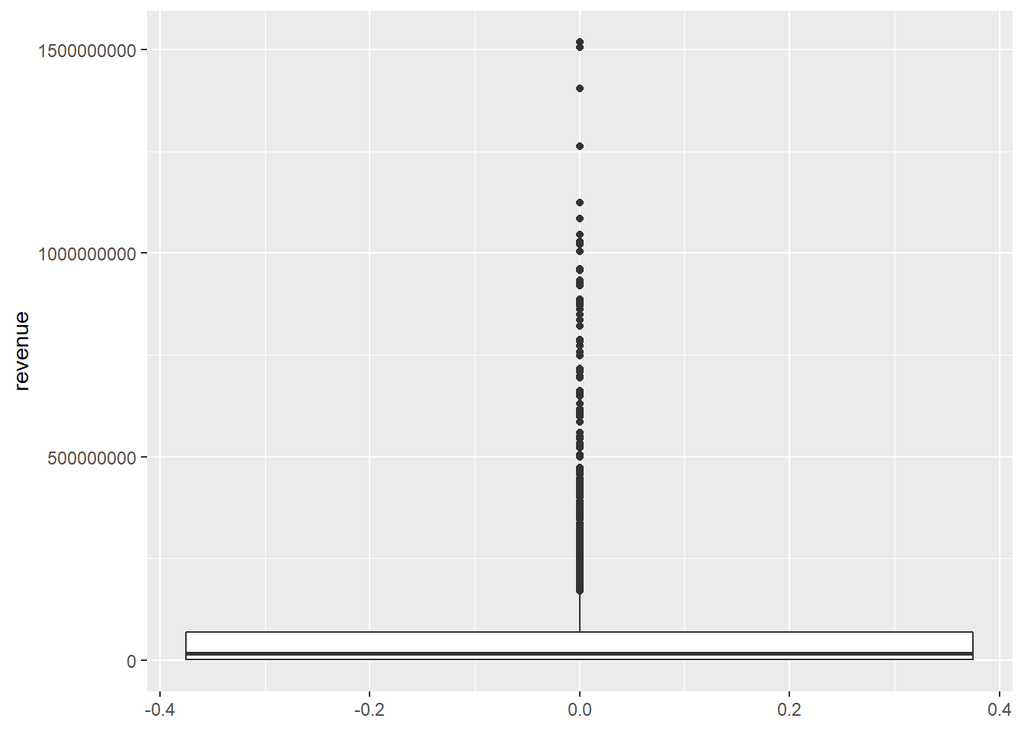

```r
par(mfrow=c(2,2))

# individual varaible analysis

options(scipen = 1000)

box_plot = ggplot(train_data, aes(y=revenue)) + geom_boxplot()
box_plot
```

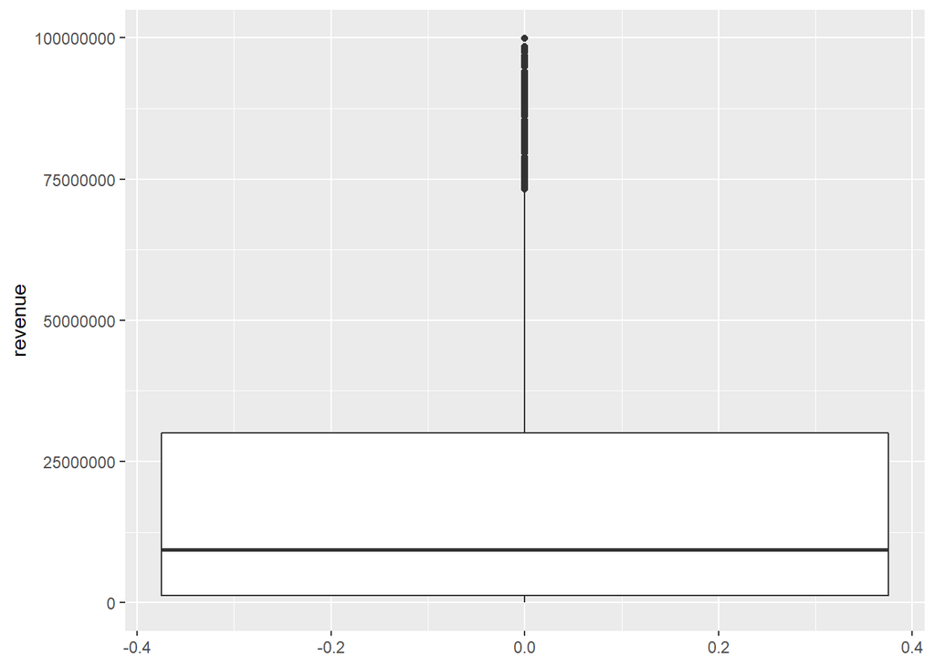

```r
box_plot = ggplot(train_data[train_data$revenue<100000000,], aes(y=revenue)) + geom_boxplot() # after removing outliers
box_plot
```

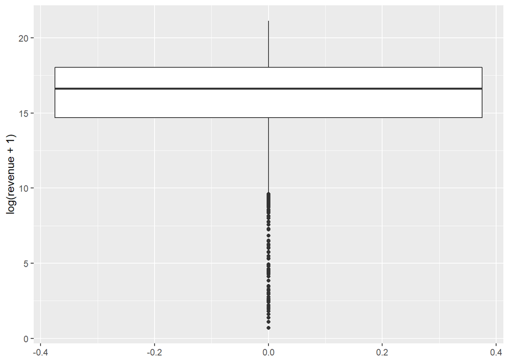

```r
box_plot =ggplot(train_data, aes(y=log(revenue+1))) + geom_boxplot()
box_plot
```

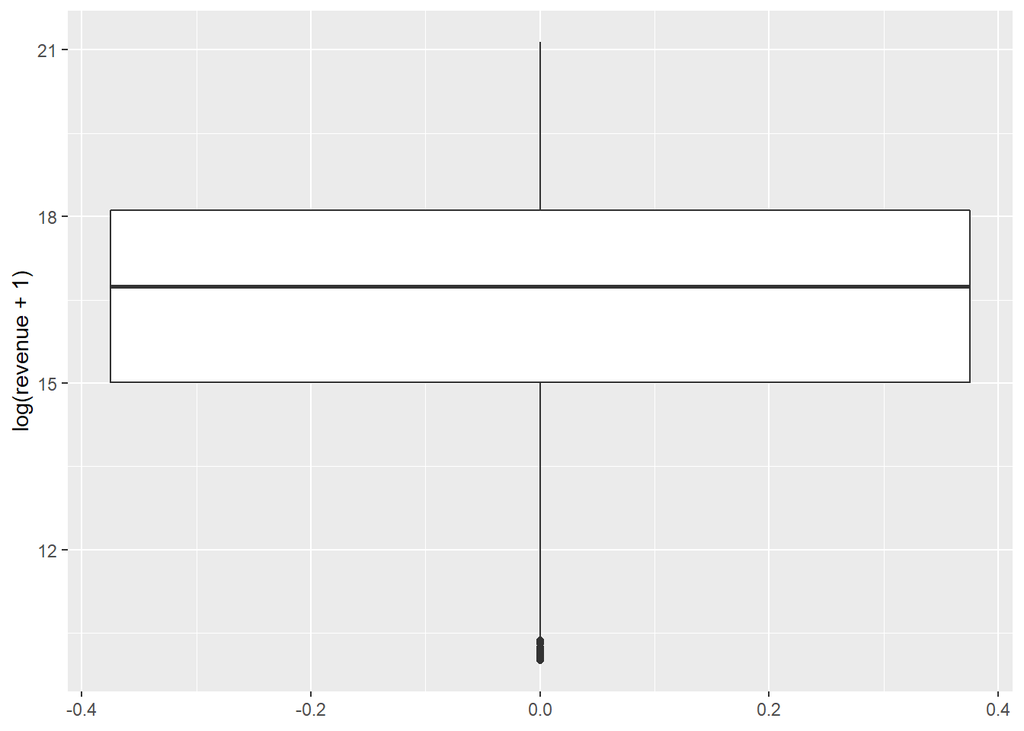

```r
box_plot = ggplot(train_data[log(train_data$revenue+1)>10,], aes(y=log(revenue+1))) + geom_boxplot()
box_plot
```

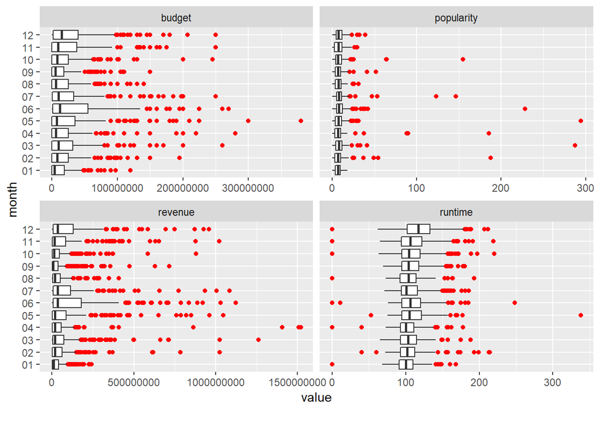

```r
plot_boxplot(train_data[,c(col_name,"month")],by = "month",nrow = 2L, ncol = 2L,
             geom_boxplot_args = list("outlier.color" = "red"))
```

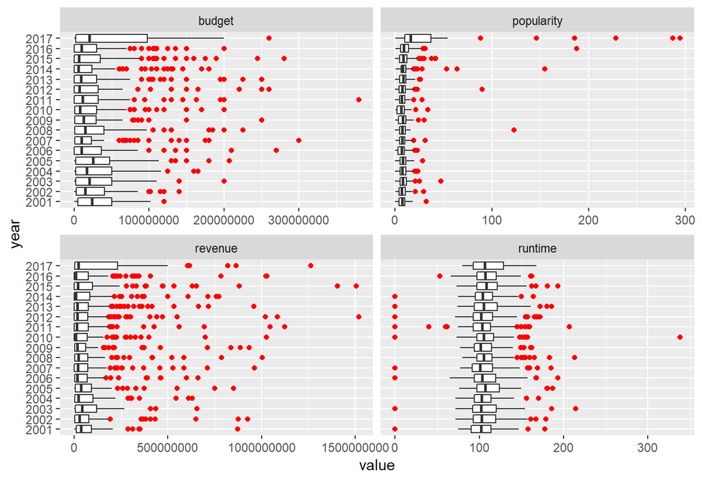

```r
plot_boxplot(train_data[as.numeric(train_data$year)>2000,c(col_name,"year")],by = "year",nrow = 2L, ncol = 2L,
             geom_boxplot_args = list("outlier.color" = "red"))
```

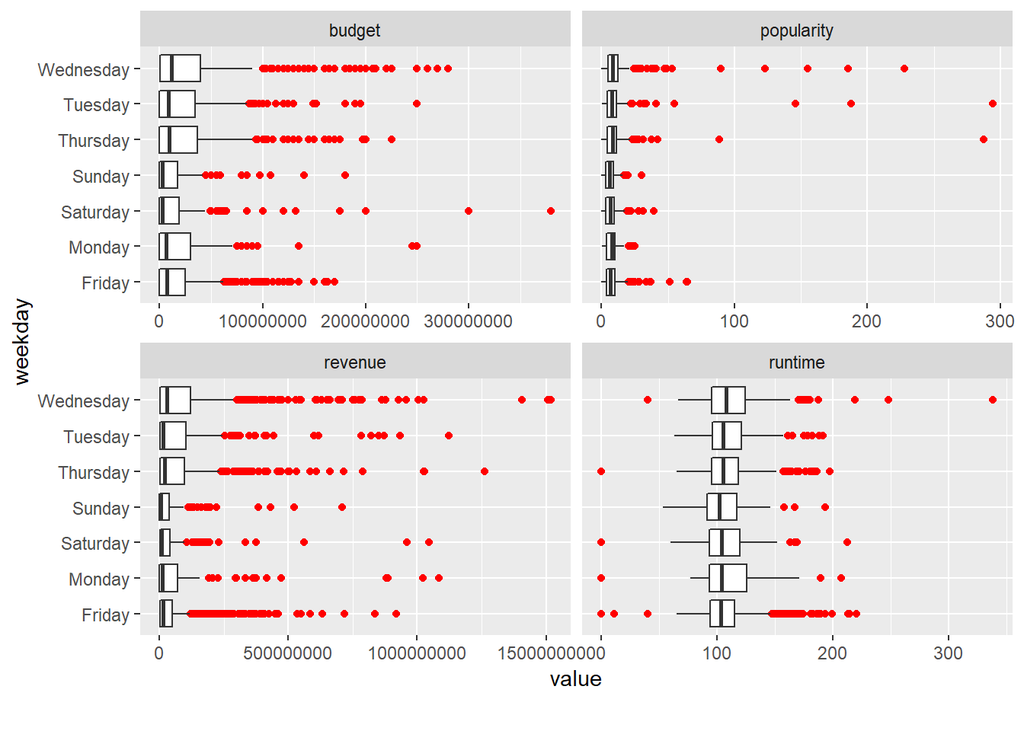

```r
plot_boxplot(train_data[,c(col_name,"weekday")],by = "weekday",nrow = 2L, ncol = 2L,
             geom_boxplot_args = list("outlier.color" = "red"))
```

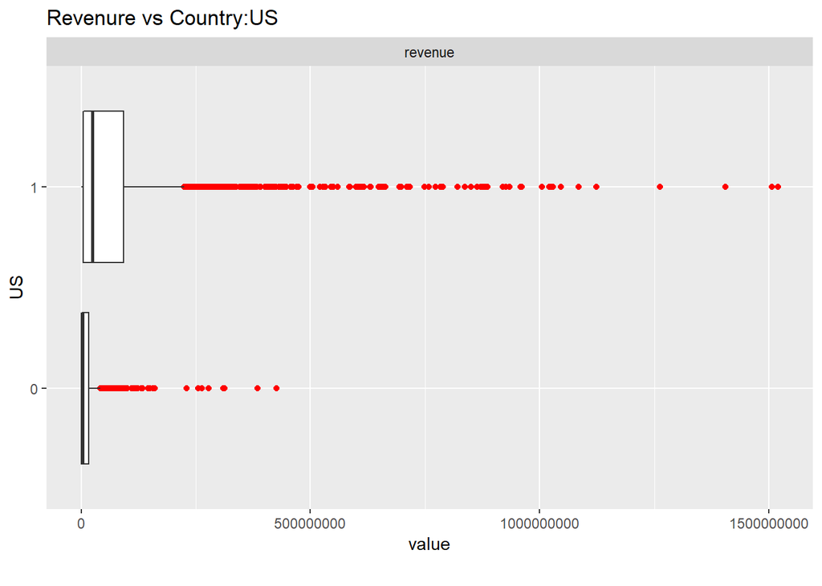

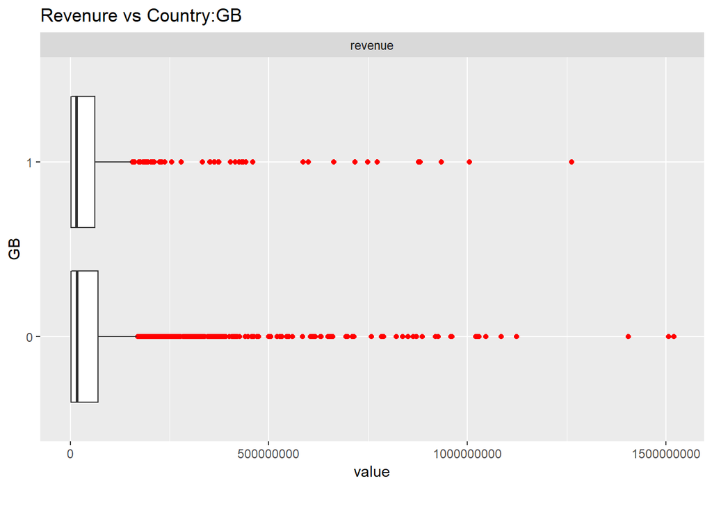

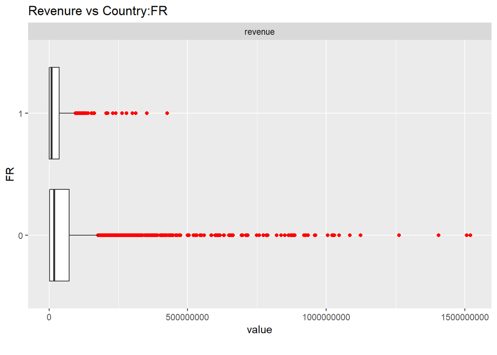

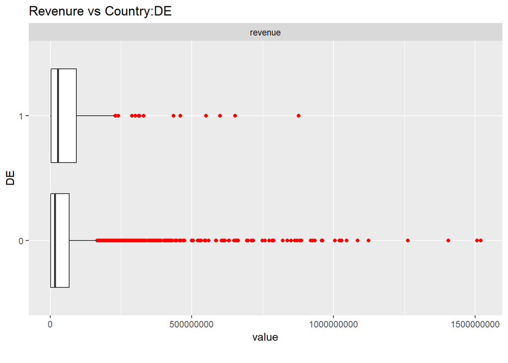

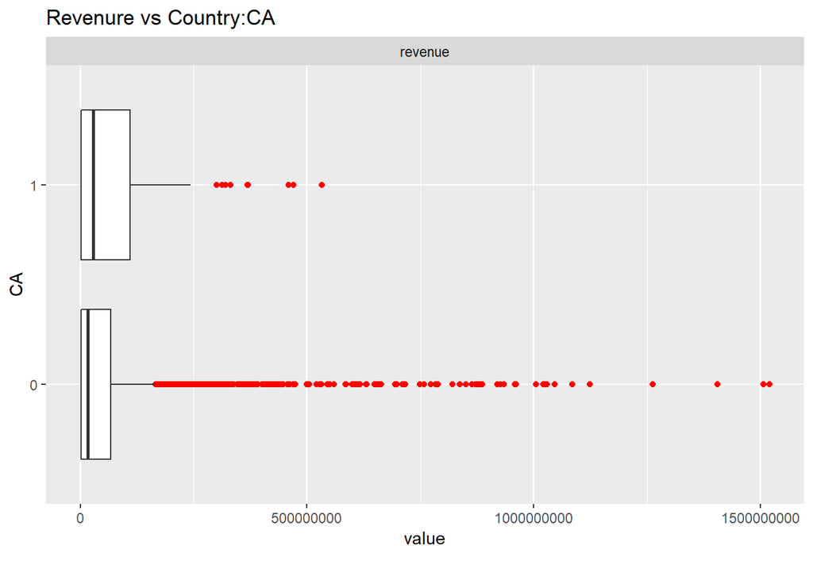

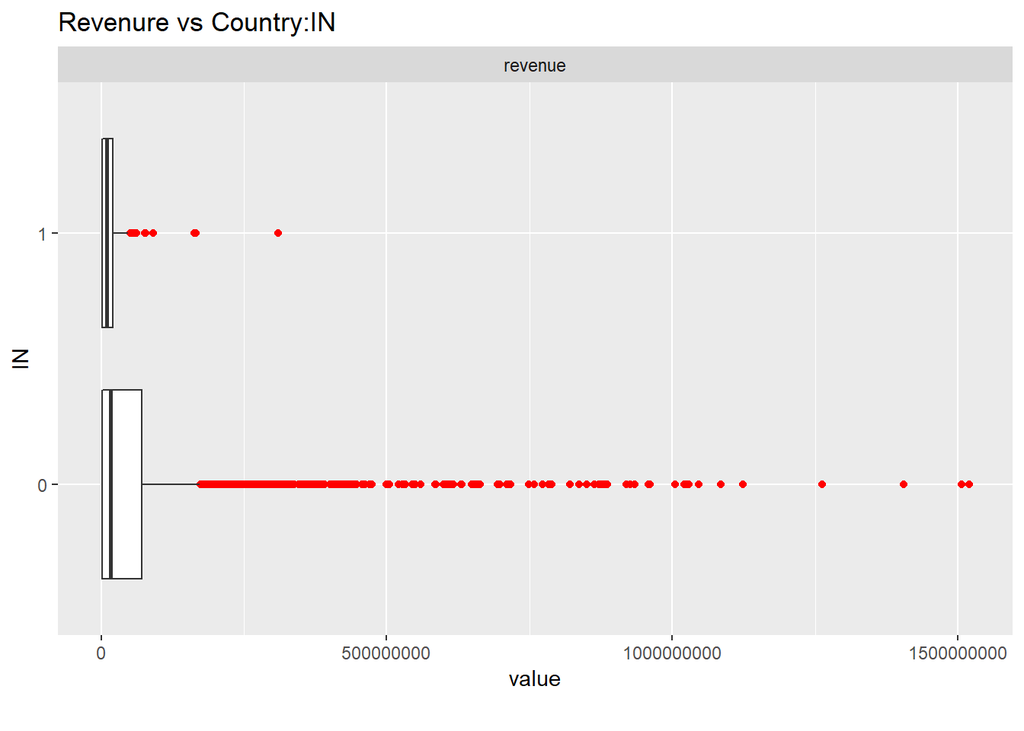

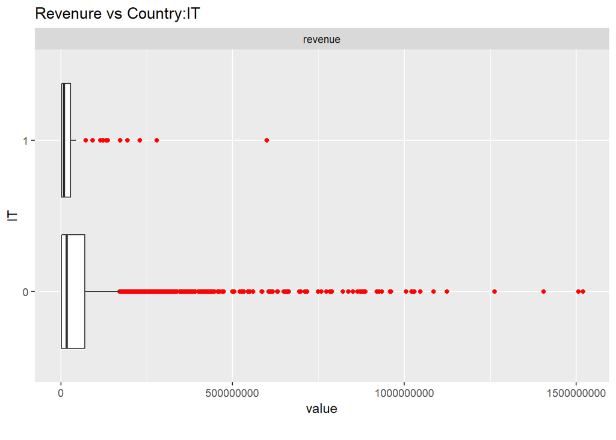

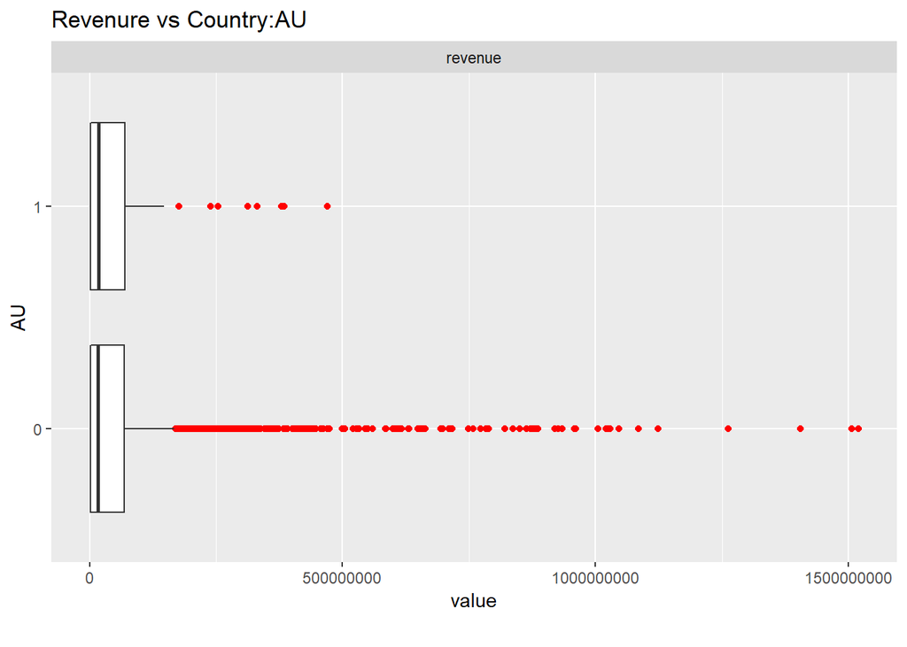

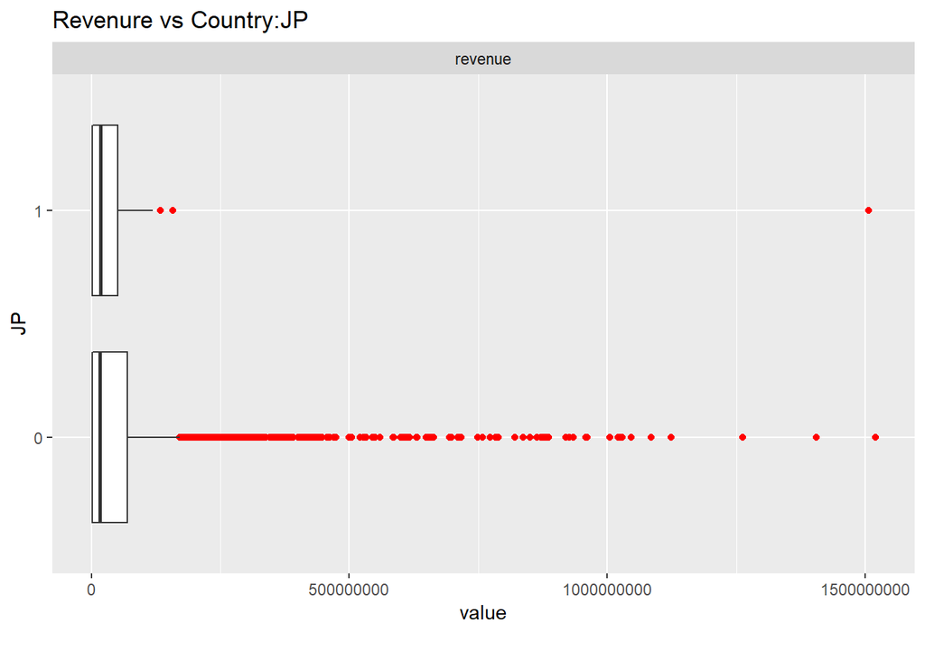

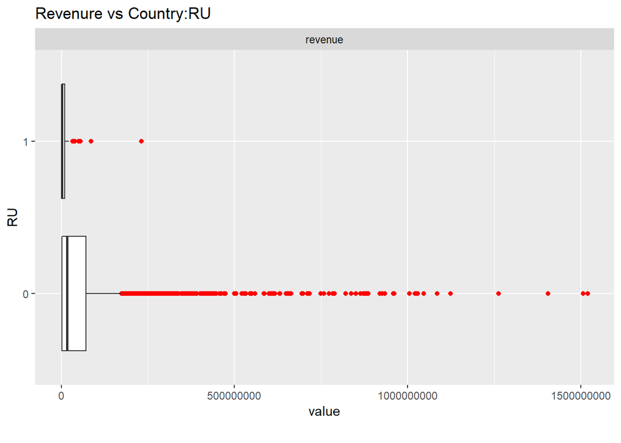

```r
# between countries and weekday

prod_count_tr_data = lapply(prod_count_tr_data,as.character)
prod_count_tr_data = data.frame(prod_count_tr_data)
temp_data = data.frame(prod_count_tr_data,revenue = train_data$revenue)


for(country in top_n_countries){

  plot_boxplot(temp_data[,c("revenue",country)],by = country,
               geom_boxplot_args = list("outlier.color" = "red"),title = paste0("Revenure vs Country:",country))

}
```

```r
prod_count_tr_data = lapply(prod_count_tr_data,as.numeric)
prod_count_tr_data = data.frame(prod_count_tr_data)
```

# # Missing Data Imputation & Feature Enginerring

```r
# 1. Drop irrelevant columns

# t1 = train_data
# t2 = test_data

#train_data = t1
#test_data = t2


train_data$oldness = Sys.Date() - train_data$release_date
test_data$oldness = Sys.Date() - test_data$release_date

drop_col = c("imdb_id","title","poster_path","crew","production_companies",
             "production_countries","genres","cast","Keywords","id","status",
             "tagline","overview","spoken_languages",
             "original_title","release_date","day")

test_id = test_data$id

train_data = train_data[,!names(train_data) %in% drop_col]
test_data = test_data[,!names(test_data) %in% drop_col]

# Scaling of numerical variable

train_data[,c("original_language","weekday")] = lapply(train_data[,c("original_language","weekday")],as.factor)
test_data[,c("original_language","weekday")] = lapply(test_data[,c("original_language","weekday")],as.factor)

train_data[,c("year","month")] = lapply(train_data[,c("year","month")],as.numeric)
test_data[,c("year","month")] = lapply(test_data[,c("year","month")],as.numeric)

str(train_data)
```

```
## Classes 'tbl_df', 'tbl' and 'data.frame':    3000 obs. of  10 variables:
##  $ runtime          : int  93 113 105 122 118 83 92 84 100 91 ...
##  $ budget           : int  14000000 40000000 3300000 1200000 0 8000000 14000000 0 0 6000000 ...
##  $ original_language: Factor w/ 6 levels "en","es","fr",..: 1 1 1 4 5 1 1 1 1 1 ...
##  $ popularity       : num  6.58 8.25 64.3 3.17 1.15 ...
##  $ revenue          : int  12314651 95149435 13092000 16000000 3923970 3261638 85446075 2586511 34327391 18750246 ...
##  $ collection_cat   : num  1 1 0 0 0 0 0 0 1 0 ...
##  $ year             : num  2015 2004 2014 2012 2009 ...
##  $ month            : num  2 8 10 3 2 8 8 1 2 4 ...
##  $ weekday          : Factor w/ 7 levels "Friday","Monday",..: 1 1 1 1 5 5 5 5 1 7 ...
##  $ oldness          : 'difftime' num  1507 5357 1640 2585 ...
##   ..- attr(*, "units")= chr "days"
```

```r
str(test_data)
```

```
## Classes 'tbl_df', 'tbl' and 'data.frame':    4398 obs. of  9 variables:
##  $ runtime          : int  90 65 100 130 92 121 119 77 120 92 ...
##  $ budget           : int  0 88000 0 6800000 2000000 0 0 30000000 16500000 90000000 ...
##  $ original_language: Factor w/ 6 levels "en","es","fr",..: 5 1 1 3 1 1 5 1 1 1 ...
##  $ popularity       : num  3.85 3.56 8.09 8.6 3.22 ...
##  $ collection_cat   : num  1 0 0 0 0 0 0 0 0 1 ...
##  $ year             : num  2007 1958 1997 2010 2005 ...
##  $ month            : num  7 5 5 9 2 2 12 2 3 10 ...
##  $ weekday          : Factor w/ 7 levels "Friday","Monday",..: 3 2 1 3 1 7 5 1 1 3 ...
##  $ oldness          : 'difftime' num  4285 22238 7989 3137 ...
##   ..- attr(*, "units")= chr "days"
```

** Missing data imputation using mice**

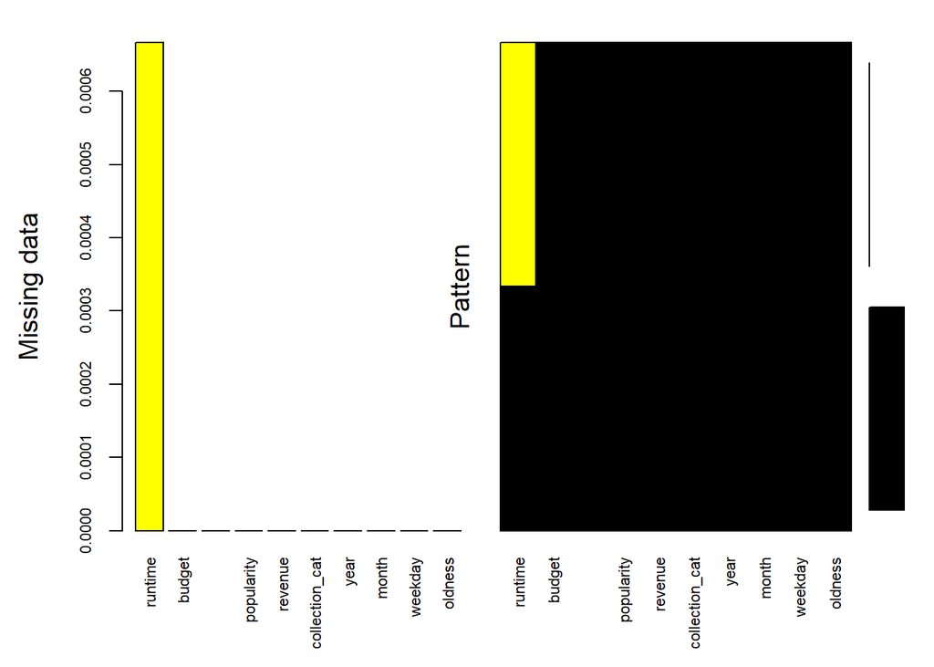

```
##
##  Variables sorted by number of missings:
##           Variable        Count
##            runtime 0.0006666667
##             budget 0.0000000000
##  original_language 0.0000000000
##         popularity 0.0000000000
##            revenue 0.0000000000
##     collection_cat 0.0000000000
##               year 0.0000000000
##              month 0.0000000000
##            weekday 0.0000000000
##            oldness 0.0000000000
```

```r
# Missing data plot and imputation

# missing data in train data
miss_plot <- aggr(train_data, col=c('black','yellow'),
                  numbers=TRUE, sortVars=TRUE,
                  labels=names(train_data), cex.axis=.7,
                  gap=1, ylab=c("Missing data","Pattern")) # no missing values
```

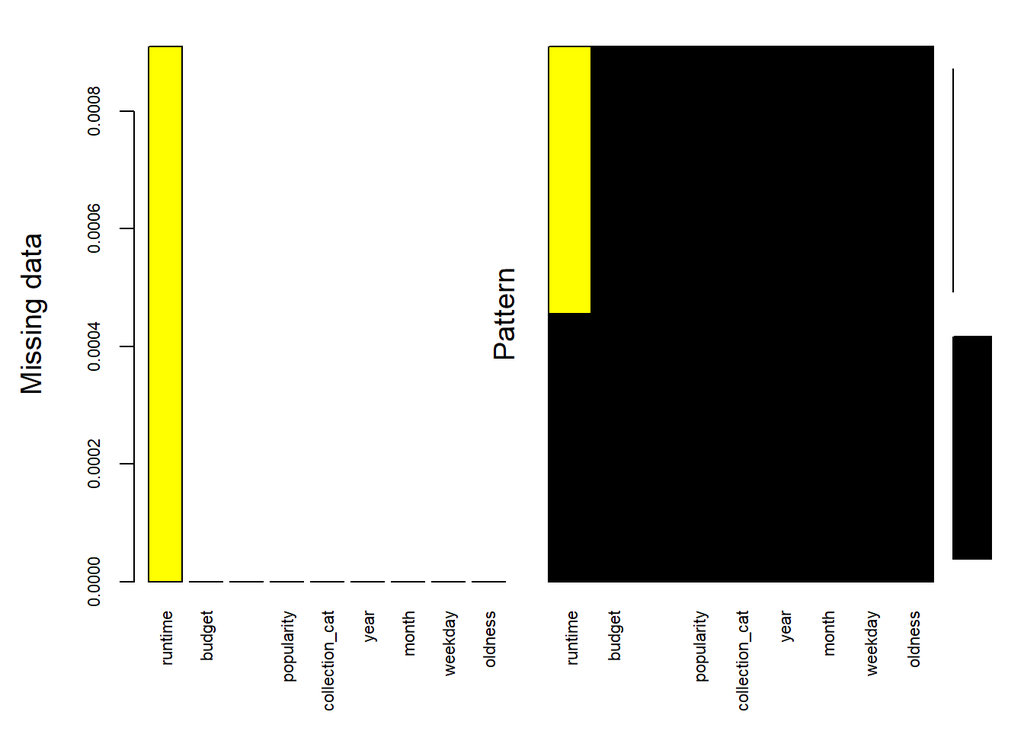

```
##
##  Variables sorted by number of missings:
##           Variable        Count
##            runtime 0.0009095043
##             budget 0.0000000000
##  original_language 0.0000000000
##         popularity 0.0000000000
##     collection_cat 0.0000000000
##               year 0.0000000000
##              month 0.0000000000
##            weekday 0.0000000000
##            oldness 0.0000000000
```

```r
# missing data in test data
miss_plot <- aggr(test_data, col=c('black','yellow'),
                  numbers=TRUE, sortVars=TRUE,
                  labels=names(test_data), cex.axis=.7,
                  gap=1, ylab=c("Missing data","Pattern")) # no missing values
```

```r
imp.runtim <- mice(train_data[,names(train_data) %in% c("popularity","runtime","budget")], m=1, method='cart', printFlag=TRUE)
imp.runtim = mice::complete(imp.runtim)
train_data$runtime = imp.runtim$runtime

imp.runtim <- mice(test_data[,names(test_data) %in% c("popularity","runtime","budget")], m=1, method='cart', printFlag=TRUE)
imp.runtim = mice::complete(imp.runtim)
test_data$runtime = imp.runtim$runtime

summary(train_data$runtime)
```

```
##    Min. 1st Qu.  Median    Mean 3rd Qu.    Max.
##     0.0    94.0   104.0   107.9   118.0   338.0
```

```r
summary(test_data$runtime)
```

```
##    Min. 1st Qu.  Median    Mean 3rd Qu.    Max.
##     0.0    94.0   104.0   107.6   118.0   320.0
```

** Gather all new created variables**

```r
## Add new created variables

train_data = data.frame(train_data,
                        dept = dept_tr_data,
                        genre = genre_tr_data,
                        keywrds = keywrds_tr_data,
                        lang = lang_tr_data,
                        prod_comp = prod_comp_tr_data,
                        prod_count = prod_count_tr_data,
                        crew_gender_0 = total_tr_crew_gender_0,
                        crew_gender_1= total_tr_crew_gender_1,
                        gender_0 = total_tr_gender_0,
                        gender_1 = total_tr_gender_1,
                        overview = overview_tr_data)

test_data = data.frame(test_data,
                       dept = dept_te_data,
                       genre = genre_te_data,
                       keywrds = keywrds_te_data,
                       lang = lang_te_data,
                       prod_comp = prod_comp_te_data,
                       prod_count = prod_count_te_data,
                       crew_gender_0 = total_te_crew_gender_0,
                       crew_gender_1 = total_te_crew_gender_1,
                       gender_0 = total_te_gender_0,
                       gender_1 = total_te_gender_1,
                       overview = overview_te_data)

encoder = onehot(train_data)
train_data = predict(encoder,train_data)

encoder = onehot(test_data)
test_data = predict(encoder,test_data)

train_data = data.frame(train_data)
test_data = data.frame(test_data)

# Removing Zero- and Near Zero-Variance Predictors

revenue = train_data$revenue
train_data$revenue = NULL

# just to make sure orders are same

test_data = test_data[,colnames(train_data)]

nzv <- nearZeroVar(train_data)
non_var_data <- train_data[, -nzv]
dim(non_var_data)
```

```
## [1] 3000   64
```

```r
non_variance_vars = names(non_var_data)

train_data = train_data[,non_variance_vars]
test_data = test_data[,non_variance_vars]
```

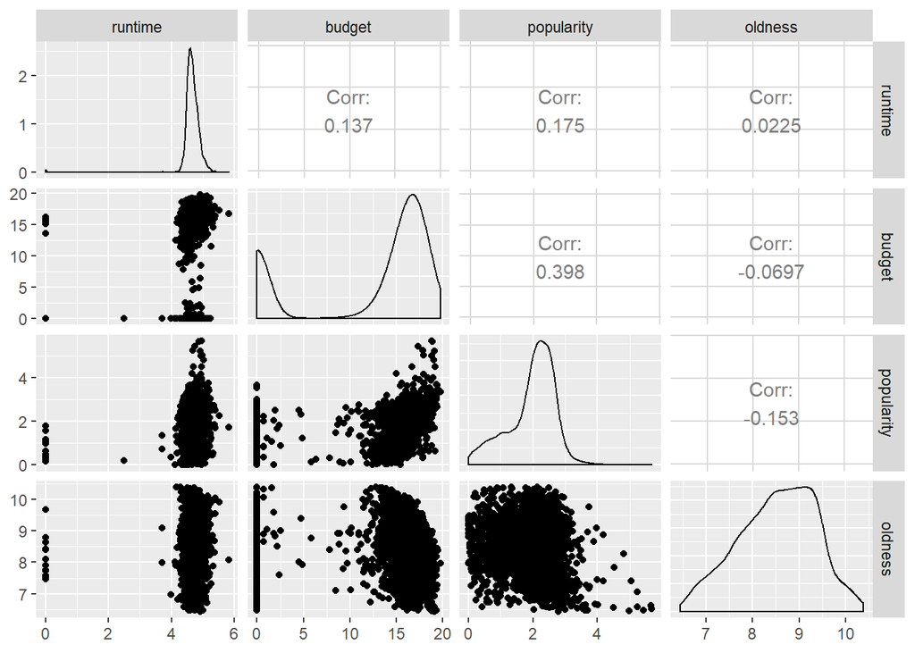

```r
# preProcValues <- preProcess(train_data[,c("popularity","budget","runtime")], method = c("center", "scale"))
# trainTransformed <- predict(preProcValues, train_data[,c("popularity","budget","runtime")])
# testTransformed <- predict(preProcValues, test_data[,c("popularity","budget","runtime")])
# train_data[,c("popularity","budget","runtime")] = trainTransformed
# test_data[,c("popularity","budget","runtime")] = testTransformed

# creating new variables based on pattern

ggpairs(log(train_data[,c("runtime","budget","popularity","oldness")]+1), alpha = 0.4) # taking log of variables
```

```r
summary(train_data$budget)
```

```
##      Min.   1st Qu.    Median      Mean   3rd Qu.      Max.
##         0         0   8000000  22531334  29000000 380000000
```

```r
train_data$budget_cat = ifelse(log(train_data$budget+1)<10,1,0)
train_data$popularity_cat = ifelse(log(train_data$popularity+1)<1.5,1,
                                   ifelse(log(train_data$popularity+1)>3.5,3,2))

test_data$budget_cat = ifelse(log(test_data$budget+1)<10,1,0)
test_data$popularity_cat = ifelse(log(test_data$popularity+1)<1.5,1,
                                   ifelse(log(test_data$popularity+1)>3.5,3,2))

# Centering and Scaling or log

train_data$budget = log(train_data$budget+1)
train_data$runtime = log(train_data$runtime+1)
train_data$popularity = log(train_data$popularity+1)

test_data$budget = log(test_data$budget+1)
test_data$runtime = log(test_data$runtime+1)
test_data$popularity = log(test_data$popularity+1)

train_data$popular_run = train_data$popularity * train_data$runtime
test_data$popular_run = test_data$popularity * test_data$runtime

train_data$budg_popular = train_data$budget/train_data$popularity
test_data$budg_popular = test_data$budget/test_data$popularity
```

# Outliers Detection

```r
mlof <- lof(train_data[,c("budget","popularity","runtime")], k=5)
quantile(mlof) # check the probablity distribution of mlof
```

```
##         0%        25%        50%        75%       100%
##  0.8778425  0.9985344  1.0393255  1.1170469 12.5193995
```

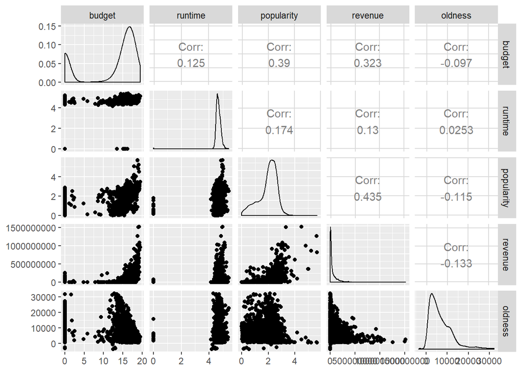

```r
thresh = quantile(mlof, .90) #  set95 percent's value as a threshold to decide the value as an outlier.
#we can change it and play with this cut-off
out_index=which(mlof>=thresh)

train_data = train_data[-out_index,]
new_revenue = revenue[-out_index]

# Add target variable
train_data$revenue = new_revenue
train_data$logRevenue = log(train_data$revenue+1)

# let's see plot after outlier removal

ggpairs(train_data[,c(col_name,"oldness")], alpha = 0.4)
```

# Model Fitting

** RANDOM FOREST **

```r
# Spliiting data into training & validation

set.seed(100)

index = createDataPartition(train_data[,"revenue"], p = 0.7, list = FALSE)
train = train_data[index, ]
val = train_data[-index, ]

#### Model Fitting ####

# 1. RANDOM FOREST

h2o.init(nthreads=-1)
```

```
##  Connection successful!
##
## R is connected to the H2O cluster:
##     H2O cluster uptime:         2 hours 8 minutes
##     H2O cluster timezone:       Asia/Kolkata
##     H2O data parsing timezone:  UTC
##     H2O cluster version:        3.23.0.4554
##     H2O cluster version age:    2 months and 14 days
##     H2O cluster name:           H2O_started_from_R_MFM_03_xyc245
##     H2O cluster total nodes:    1
##     H2O cluster total memory:   3.05 GB
##     H2O cluster total cores:    4
##     H2O cluster allowed cores:  4
##     H2O cluster healthy:        TRUE
##     H2O Connection ip:          localhost
##     H2O Connection port:        54321
##     H2O Connection proxy:       NA
##     H2O Internal Security:      FALSE
##     H2O API Extensions:         Algos, AutoML, Core V3, Core V4
##     R Version:                  R version 3.5.1 (2018-07-02)
```

```r
## Load train, val, & test data into cluster from R

trainHex<-as.h2o(train)
valHex<-as.h2o(val)
testHex<-as.h2o(test_data)
rfHex <- h2o.randomForest(x=names(train[,!names(train) %in% c("revenue","logRevenue")]),
                          y="logRevenue",
                          ntrees = 100,
                          #sample_rate_per_class = c(0.125,0.99,0.99,0.12),
                          training_frame=trainHex,
                          validation_frame = valHex,
                          nfolds = 3,
                          seed = 9,
                          score_each_iteration = TRUE,
                          keep_cross_validation_predictions = TRUE)
summary(rfHex)
```

```
## Model Details:
## ==============
##
## H2ORegressionModel: drf
## Model Key:  DRF_model_R_1554612863061_9
## Model Summary:
##   number_of_trees number_of_internal_trees model_size_in_bytes min_depth
## 1             100                      100             1463494        20
##   max_depth mean_depth min_leaves max_leaves mean_leaves
## 1        20   20.00000       1101       1199  1154.79000
##
## H2ORegressionMetrics: drf
## ** Reported on training data. **
## ** Metrics reported on Out-Of-Bag training samples **
##
## MSE:  4.553224
## RMSE:  2.133828
## MAE:  1.413585
## RMSLE:  0.1965057
## Mean Residual Deviance :  4.553224
##
##
## H2ORegressionMetrics: drf
## ** Reported on validation data. **
##
## MSE:  3.865424
## RMSE:  1.966068
## MAE:  1.317526
## RMSLE:  0.1806812
## Mean Residual Deviance :  3.865424
##
##
## H2ORegressionMetrics: drf
## ** Reported on cross-validation data. **
## ** 3-fold cross-validation on training data (Metrics computed for combined holdout predictions) **
##
## MSE:  4.529183
## RMSE:  2.128188
## MAE:  1.413342
## RMSLE:  0.1958868
```

[output cut: 75 more lines]

```
## ---
##                        variable relative_importance scaled_importance
## 63        prod_comp.Warner.Bros         2033.688354          0.007204
## 64 prod_comp.Universal.Pictures         1734.526489          0.006144
## 65                      lang.ru         1630.842896          0.005777
## 66                 genre.Scienc         1515.355835          0.005368
## 67                genre.Fiction         1478.927979          0.005239
## 68  prod_comp.Columbia.Pictures          722.286255          0.002558
##    percentage
## 63   0.001699
## 64   0.001449
## 65   0.001362
## 66   0.001266
## 67   0.001235
## 68   0.000603
```

```r
## validation revenue prediction

cat("Predicting Revenue using RANDOM FOREST\n")
```

```
## Predicting Revenue using RANDOM FOREST
```

```r
h2o_rf_predict<-as.data.frame(h2o.predict(rfHex,valHex))
```

```r
cat("RANDOM FOREST MAPE : " ,(sum(abs(val$logRevenue-h2o_rf_predict$predict))/sum(val$logRevenue))*100,"\n")
```

```
## RANDOM FOREST MAPE :  8.166273
```

```r
cat("RANDOM FOREST RMSE: ",rmse(val$logRevenue, h2o_rf_predict$predict),"\n")
```

```
## RANDOM FOREST RMSE:  1.966068
```

```r
cat("Correlation between prediction & actual : ",cor(val$logRevenue,h2o_rf_predict),"\n")
```

```
## Correlation between prediction & actual :  0.7102687
```

```r
rm(h2o_rf_predict)

# test revenue prediction
h2o_rf_test_predict<-as.data.frame(h2o.predict(rfHex,testHex))
h2o_rf_test_predict = exp(h2o_rf_test_predict$predict)

submission = data.frame(id = test_id,revenue=h2o_rf_test_predict)
write.csv(submission, file = "test_output_rf.csv",row.names=FALSE)

# find importance
varimp <- h2o.varimp(rfHex)
varimp
```

```
## Variable Importances:
##      variable relative_importance scaled_importance percentage
## 1      budget       282312.625000          1.000000   0.235829
## 2 popular_run       139899.218750          0.495547   0.116864
## 3  popularity       115771.132812          0.410081   0.096709
## 4     oldness        54277.160156          0.192259   0.045340
## 5  budget_cat        50335.976562          0.178299   0.042048
##
## ---
##                        variable relative_importance scaled_importance
## 63        prod_comp.Warner.Bros         2033.688354          0.007204
## 64 prod_comp.Universal.Pictures         1734.526489          0.006144
## 65                      lang.ru         1630.842896          0.005777
## 66                 genre.Scienc         1515.355835          0.005368
## 67                genre.Fiction         1478.927979          0.005239
## 68  prod_comp.Columbia.Pictures          722.286255          0.002558
##    percentage
## 63   0.001699
## 64   0.001449
## 65   0.001362
## 66   0.001266
## 67   0.001235
## 68   0.000603
```

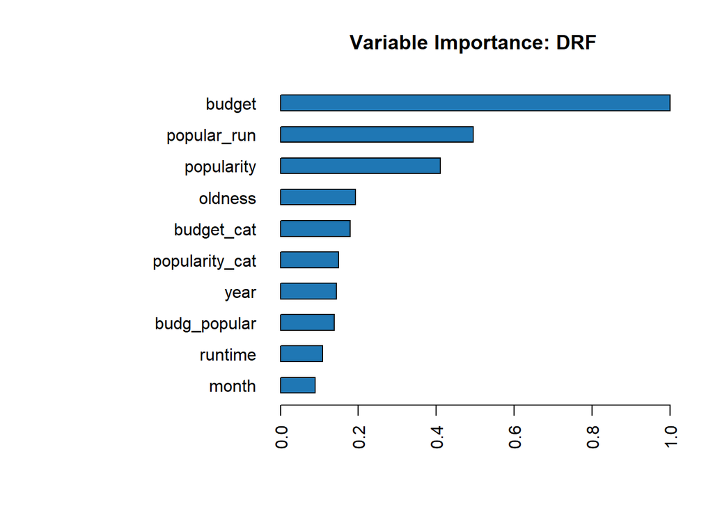

```r
h2o.varimp_plot(rfHex)
```

** GBM**

```r
# 2. GBM


library(iterators)
library(parallel)
library(doMC)
library(Metrics)

set.seed(222)
detectCores()
```

```
## [1] 4
```

```r
registerDoMC(4)
## Set up caret model training parameters
trail_ctrl <- trainControl(method = "cv", number = 3,
                                 verboseIter = FALSE, allowParallel = TRUE)

gbmFit <- train(logRevenue ~ ., method = "gbm",
                metric = "RMSE",
                maximize = FALSE,
                trControl = trail_ctrl,
                tuneGrid = expand.grid(n.trees = (4:10) * 50,
                                       interaction.depth = c(3,5,10),
                                       shrinkage = c(0.05),
                                       n.minobsinnode = c(10,15,20)),
                data = train[,!names(train) %in% "revenue"], verbose = FALSE)

print(gbmFit)
```

```
## Stochastic Gradient Boosting
##
## 1892 samples
##   68 predictor
##
## No pre-processing
## Resampling: Cross-Validated (3 fold)
## Summary of sample sizes: 1260, 1263, 1261
## Resampling results across tuning parameters:
##
##   interaction.depth  n.minobsinnode  n.trees  RMSE      Rsquared
##    3                 10              200      2.127911  0.4951154
##    3                 10              250      2.125270  0.4970371
##    3                 10              300      2.125278  0.4973170
##    3                 10              350      2.126198  0.4977120
##    3                 10              400      2.134943  0.4942542
##    3                 10              450      2.137810  0.4933491
##    3                 10              500      2.136097  0.4940747
##    3                 15              200      2.127595  0.4954335
##    3                 15              250      2.130260  0.4949322
##    3                 15              300      2.138579  0.4925080
##    3                 15              350      2.141618  0.4903401
##    3                 15              400      2.140567  0.4914724
##    3                 15              450      2.142962  0.4904802
##    3                 15              500      2.144179  0.4907420
##    3                 20              200      2.110773  0.5033886
##    3                 20              250      2.113244  0.5022813
##    3                 20              300      2.116480  0.5009108
##    3                 20              350      2.124876  0.4977217
##    3                 20              400      2.123446  0.4979003
##    3                 20              450      2.130807  0.4957673
##    3                 20              500      2.134726  0.4943593
##    5                 10              200      2.113956  0.5035321
##    5                 10              250      2.120870  0.5000547
##    5                 10              300      2.126511  0.4983046
##    5                 10              350      2.132321  0.4960334
##    5                 10              400      2.135129  0.4949777
##    5                 10              450      2.142168  0.4924621
##    5                 10              500      2.148658  0.4896805
##    5                 15              200      2.129377  0.4957923
```

[output cut: 88 more lines]

```
##   1.412704
##   1.419639
##   1.423612
##   1.375388
##   1.385510
##   1.386665
##   1.388821
##   1.400324
##   1.401863
##   1.409812
##
## Tuning parameter 'shrinkage' was held constant at a value of 0.05
## RMSE was used to select the optimal model using the smallest value.
## The final values used for the model were n.trees = 200,
##  interaction.depth = 10, shrinkage = 0.05 and n.minobsinnode = 20.
```

```r
cat("Predicting Revenue using GBM\n")
```

```
## Predicting Revenue using GBM
```

```r
## valiation prediction
gbm_pred <- predict(gbmFit, newdata = val)

cat("GBM MAPE : " ,(sum(abs(val$logRevenue-gbm_pred))/sum(val$logRevenue))*100,"\n")
```

```
## GBM MAPE :  8.067186
```

```r
 cat("GBM RMSE: ",rmse(val$logRevenue, gbm_pred),"\n")
```

```
## GBM RMSE:  1.937532
```

```r
cat("Correlation between prediction & actual : ",cor(gbm_pred,val$logRevenue),"\n")
```

```
## Correlation between prediction & actual :  0.7204951
```

```r
# test prediction
gbm_test_pred = predict(gbmFit, newdata = test_data)
submission = data.frame(id = test_id,revenue=exp(gbm_test_pred))
write.csv(submission, file = "test_output_gbm.csv",row.names=FALSE)
```

** XGBOOST **

```r
# 3. XGBOOST

options(scipen = 1000)

library(xgboost)
set.seed(123)
## Model parameters trained using xgb.cv function

xgtrain <- xgb.DMatrix(as.matrix(train[,!names(train) %in% c("revenue","logRevenue")]), label = train$logRevenue)
xgval <- xgb.DMatrix(as.matrix(val[,!names(train) %in% c("revenue","logRevenue")]), label = val$logRevenue)
xgtest <- xgb.DMatrix(as.matrix(test_data))


param <- list(booster="gbtree",
              eta=0.01,
              colsample_bytree = 0.3,
              max_depth = 5,
              min_child_weight = 2,
              subsample = 0.9,
              base_score = mean(train$logRevenue))

set.seed(99)

xgbcv <- xgb.cv( params = param,
                 data = xgtrain,
                 nrounds = 1000, nfold = 5,
                 showsd = T, stratified = T,
                 print.every.n = 10, early.stop.round = 20, maximize = F)
```

```
## Multiple eval metrics are present. Will use test_rmse for early stopping.
## Will train until test_rmse hasn't improved in 20 rounds.
##
## Stopping. Best iteration:
```

```r
xgbcv$best_iteration
```

```
## [1] 649
```

```r
xgbcv$best_ntreelimit
```

```
## [1] 649
```

```r
min(xgbcv$evaluation_log$test_rmse_mean)
```

```
## [1] 2.079232
```

```r
mod.xgb <- xgb.train(data=xgtrain,
                     params = param, nrounds= xgbcv$best_iteration,print_every_n = 50,
                     watchlist = list(train=xgtrain, val=xgval))
cat("Predicting Revenue using XGBOOST\n")
```

```
## Predicting Revenue using XGBOOST
```

```r
xgb_pred = predict(mod.xgb, newdata = xgval)

cat("XGBOOST MAPE : " ,(sum(abs(val$logRevenue-xgb_pred))/sum(val$logRevenue))*100,"\n") # MAPE validation error
```

```
## XGBOOST MAPE :  7.901881
```

```r
cat("XGBOOST RMSE: ",rmse(val$logRevenue, xgb_pred),"\n")
```

```
## XGBOOST RMSE:  1.909717
```

```r
cat("Correlation between prediction & actual : ",cor(xgb_pred,val$logRevenue),"\n")
```

```
## Correlation between prediction & actual :  0.725921
```

```r
xgb_test_pred = predict(mod.xgb, newdata = xgtest)
xgb_test_pred = exp(xgb_test_pred)
submission = data.frame(id = test_id,revenue=xgb_test_pred)
write.csv(submission, file = "test_output_xgboost.csv",row.names=FALSE)
```

** H2O AUTO ML **

```r
# H20 AUTO ML

h2o_aml <- h2o.automl(x=names(train[,!names(train) %in% c("revenue","logRevenue")]),
                      y="logRevenue",
                      training_frame = trainHex,
                      validation_frame = valHex,
                      max_models = 5,
                      seed = 99,
                      nfolds = 3)
lb <- h2o_aml@leaderboard
print(lb, n = nrow(lb))
```

```
##                                              model_id
## 1    StackedEnsemble_AllModels_AutoML_20190407_123459
## 2 StackedEnsemble_BestOfFamily_AutoML_20190407_123459
## 3                        GBM_2_AutoML_20190407_123459
## 4                        GBM_1_AutoML_20190407_123459
## 5                        DRF_1_AutoML_20190407_123459
## 6                        XRT_1_AutoML_20190407_123459
## 7           GLM_grid_1_AutoML_20190407_123459_model_1
##   mean_residual_deviance     rmse      mse      mae     rmsle
## 1               4.511130 2.123942 4.511130 1.382593 0.1966371
## 2               4.514104 2.124642 4.514104 1.382212 0.1966047
## 3               4.558853 2.135147 4.558853 1.395227 0.1965202
## 4               4.806933 2.192472 4.806933 1.441670 0.2007082
## 5               4.899234 2.213421 4.899234 1.456620 0.2011398
## 6               4.950826 2.225045 4.950826 1.476531 0.2017629
## 7               5.192366 2.278676 5.192366 1.541941 0.2057457
##
## [7 rows x 6 columns]
```

```r
cat("Predicting Revenue using H2O AUTO ML\n")
```

```
## Predicting Revenue using H2O AUTO ML
```

```r
h2o_aml_predict<-as.data.frame(h2o.predict(h2o_aml,valHex))
```

```r
cat("AUTO ML MAPE: ",(sum(abs(val$logRevenue-h2o_aml_predict$predict))/sum(val$logRevenue))*100,"\n")
```

```
## AUTO ML MAPE:  7.934945
```

```r
cat("AUTO ML RMSE: ",rmse(val$logRevenue, h2o_aml_predict$predict),"\n")
```

```
## AUTO ML RMSE:  1.918164
```

```r
cat("Correlation between prediction & actual : ", cor(val$logRevenue,h2o_aml_predict$predict),"\n")
```

```
## Correlation between prediction & actual :  0.7238475
```

```r
rm(h2o_aml_predict)

# test revenue prediction
h2o_aml_test_predict<-as.data.frame(h2o.predict(h2o_aml,testHex))
h2o_aml_test_predict = exp(h2o_aml_test_predict$predict)

submission = data.frame(id = test_id,revenue=h2o_aml_test_predict)
write.csv(submission, file = "test_output_aml.csv",row.names=FALSE)
```